# Practical ML Project

Muhammad Imdad Ullah

7/2/2020

## Overview

Using devices such as Jawbone Up, Nike FuelBand, and Fitbit it is now possible to collect a large amount of data about personal activity relatively inexpensively. These type of devices are part of the quantified self movement - a group of enthusiasts who take measurements about themselves regularly to improve their health, to find patterns in their behavior, or because they are tech geeks. One thing that people regularly do is quantify how much of a particular activity they do, but they rarely quantify how well they do it.

In this project, we will use data from accelerometers on the belt, forearm, arm, and dumbell of 6 participants. They were asked to perform barbell lifts correctly and incorrectly in 5 different ways.

The data consists of a Training data and a Test data (to be used to validate the selected model). The goal is to predict the manner in which we did the exercise in our course. This is the “classe” variable in the training set. You may use any of the other variables to predict with.

Note: The dataset used in this project is a courtesy of “Ugulino, W.; Cardador, D.; Vega, K.; Velloso, E.; Milidiu, R.; Fuks, H. Wearable Computing: Accelerometers’ Data Classification of Body Postures and Movements”

## Library and Data Loading

```r
library(caret)
```

```r
library(rpart)
library(rpart.plot)
library(randomForest)
library(corrplot)
library(RColorBrewer)
library(rattle)
library(gbm)
```

### Downloading Data

```r
trainUrl <- "https://d396qusza40orc.cloudfront.net/predmachlearn/pml-training.csv"
testUrl <- "https://d396qusza40orc.cloudfront.net/predmachlearn/pml-testing.csv"
trainFile <- "./data/pml-training.csv"
testFile  <- "./data/pml-testing.csv"
if (!file.exists("./data")) {
  dir.create("./data")
}
if (!file.exists(trainFile)) {
  download.file(trainUrl, destfile=trainFile, method="curl")
}
if (!file.exists(testFile)) {
  download.file(testUrl, destfile=testFile, method="curl")
}
```

### Read the Data

Let read the downloaded csv files into two data frames.

```r
trainRaw <- read.csv("./data/pml-training.csv")
testRaw <- read.csv("./data/pml-testing.csv")
dim(trainRaw);dim(testRaw)
```

```
## [1] 19622   160
```

```
## [1]  20 160
```

The training data set contains 19622 observations/rows and 160 column/variables, while the testing data set contains 20 observations/rows and 160 variables. The “classe” variable in the training set is the outcome to predict.

### Cleaning the data

In this step, we will clean the data and get rid of variables with missing values.

```r
sum(complete.cases(trainRaw))
```

```
## [1] 406
```

First, we remove columns that contain NA missing values.

```r
trainRaw <- trainRaw[, colSums(is.na(trainRaw)) == 0]
testRaw <- testRaw[, colSums(is.na(testRaw)) == 0]
```

Now, we get rid of some others columns that do not contribute much to the accelerometer measurements.

```r
classe <- trainRaw$classe
trainRemove <- grepl("^X|timestamp|window", names(trainRaw))
trainRaw <- trainRaw[, !trainRemove]
trainCleaned <- trainRaw[, sapply(trainRaw, is.numeric)]
trainCleaned$classe <- classe
testRemove <- grepl("^X|timestamp|window", names(testRaw))
testRaw <- testRaw[, !testRemove]
testCleaned <- testRaw[, sapply(testRaw, is.numeric)]
```

Now, the cleaned training data set contains 19622 observations and 53 variables, while the testing data set contains 20 observations and 53 variables.

### Preparing the datasets for prediction

Here we split the cleaned training set into a pure training data set (70%) and a validation data set (30%).

```r
set.seed(22519) # For reproducible results
inTrain <- createDataPartition(trainCleaned$classe, p=0.70, list=F)
trainData <- trainCleaned[inTrain, ]
testData <- trainCleaned[-inTrain, ]
dim(trainData); dim(testData)
```

```
## [1] 13737    53
```

```
## [1] 5885   53
```

### Visualize the Correlation Matrix

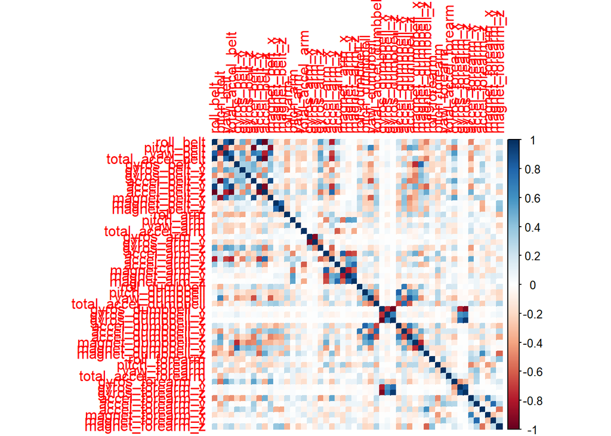

```r
library(corrplot)
corrPlot <- cor(trainData[, -length(names(trainData))])
corrplot(corrPlot, method="color")
```

## Model Building

We will use different algorithm to predict the outcome.

### Model Building with Random Forest

We fit a predictive model for activity recognition using **Random Forest** algorithm because it automatically selects important variables and is robust to correlated covariates and outliers in general. We will use **5-fold cross validation** when applying the algorithm.

```r
controlRf <- trainControl(method="cv", 5, verboseIter=FALSE)

modelRf <- train(classe ~ ., data=trainData,
                 method="rf",
                 trControl=controlRf, ntree=250)

modelRf$finalModel
```

```
##
## Call:
##  randomForest(x = x, y = y, ntree = 250, mtry = param$mtry)
##                Type of random forest: classification
##                      Number of trees: 250
## No. of variables tried at each split: 27
##
##         OOB estimate of  error rate: 0.69%
## Confusion matrix:
##      A    B    C    D    E class.error
## A 3900    5    1    0    0 0.001536098
## B   23 2628    6    1    0 0.011286682
## C    0    8 2378   10    0 0.007512521
## D    0    1   20 2227    4 0.011101243
## E    0    3    3   10 2509 0.006336634
```

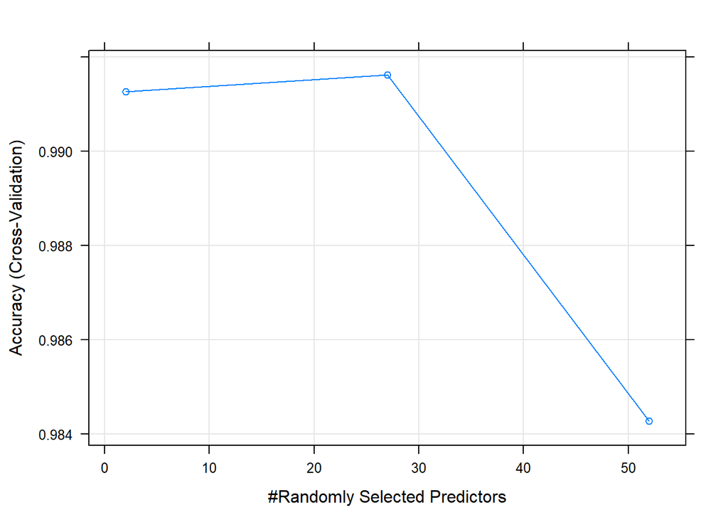

```r
plot(modelRf)
```

Let estimate the performance of the model on the validation data set.

```r
predictRf <- predict(modelRf, newdata=testData)
cmrf<-confusionMatrix(predictRf, factor(testData$classe))

accuracy <- postResample(predictRf, factor(testData$classe)); accuracy
```

```
##  Accuracy     Kappa
## 0.9937128 0.9920477
```

```r
oose <- 1 - cmrf$overall[1]; oose
```

```
##    Accuracy
## 0.006287171
```

So, the estimated accuracy of the model is 99.37% and the estimated out-of-sample error is 0.63%.

## Predicting for Test Data Set

Now, we apply the model to the original testing data set downloaded from the data source. We remove the `problem_id` column first.

```r
result <- predict(modelRf, testCleaned[, -length(names(testCleaned))]);result
```

```
##  [1] B A B A A E D B A A B C B A E E A B B B
## Levels: A B C D E
```

### Model Building with Classification Trees

We first obtain the model, and then we use the `fancyRpartPlot()` function to plot the classification tree as a dendogram.

[figure not shown]

```r
set.seed(12345)
decisionTreeMod1 <- rpart(classe ~ ., data=trainData, method="class")
fancyRpartPlot(decisionTreeMod1)
```

Let validate the model “decisionTreeModel” on the testData to find out how well it performs by looking at the accuracy variable.

```r
predictTreeMod1 <- predict(decisionTreeMod1, testData, type = "class")
cmtree <- confusionMatrix(predictTreeMod1, as.factor(testData$classe))
cmtree
```

```
## Confusion Matrix and Statistics
##
##           Reference
## Prediction    A    B    C    D    E
##          A 1502  162   24   60   18
##          B   62  674   78   87   99
##          C   44  159  825   74   92
##          D   52   76   70  660   71
##          E   14   68   29   83  802
##
## Overall Statistics
##
##                Accuracy : 0.7584
##                  95% CI : (0.7472, 0.7693)
##     No Information Rate : 0.2845
##     P-Value [Acc > NIR] : < 2.2e-16
##
##                   Kappa : 0.6939
##
##  Mcnemar's Test P-Value : < 2.2e-16
##
## Statistics by Class:
##
##                      Class: A Class: B Class: C Class: D Class: E
## Sensitivity            0.8973   0.5917   0.8041   0.6846   0.7412
## Specificity            0.9373   0.9313   0.9241   0.9453   0.9596
## Pos Pred Value         0.8505   0.6740   0.6910   0.7104   0.8052
## Neg Pred Value         0.9582   0.9048   0.9572   0.9387   0.9427
## Prevalence             0.2845   0.1935   0.1743   0.1638   0.1839
## Detection Rate         0.2552   0.1145   0.1402   0.1121   0.1363
## Detection Prevalence   0.3001   0.1699   0.2029   0.1579   0.1692
## Balanced Accuracy      0.9173   0.7615   0.8641   0.8150   0.8504
```

Matrix plot

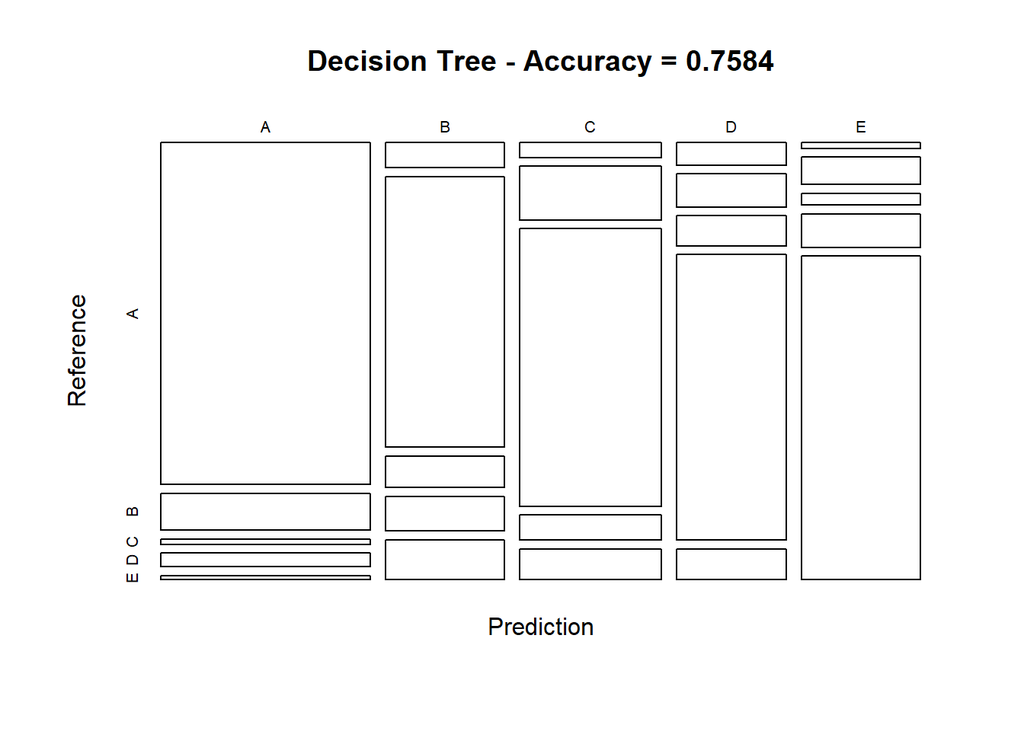

```r
plot(cmtree$table, col = cmtree$byClass,
     main = paste("Decision Tree - Accuracy =", round(cmtree$overall['Accuracy'], 4)))
```

### Model Buliding with Generalized Boosted Regression Models

```r
set.seed(12345)
controlGBM <- trainControl(method = "repeatedcv", number = 5, repeats = 1)
modGBM  <- train(classe ~ ., data=trainData, method = "gbm", trControl = controlGBM, verbose = FALSE)
modGBM$finalModel
```

```
## A gradient boosted model with multinomial loss function.
## 150 iterations were performed.
## There were 52 predictors of which 52 had non-zero influence.
```

```r
print(modGBM)
```

```
## Stochastic Gradient Boosting
##
## 13737 samples
##    52 predictor
##     5 classes: 'A', 'B', 'C', 'D', 'E'
##
## No pre-processing
## Resampling: Cross-Validated (5 fold, repeated 1 times)
## Summary of sample sizes: 10990, 10990, 10989, 10991, 10988
## Resampling results across tuning parameters:
##
##   interaction.depth  n.trees  Accuracy   Kappa
##   1                   50      0.7460870  0.6780232
##   1                  100      0.8176435  0.7691750
##   1                  150      0.8529503  0.8138636
##   2                   50      0.8502588  0.8102589
##   2                  100      0.9051458  0.8799419
##   2                  150      0.9317167  0.9135889
##   3                   50      0.8918238  0.8629926
##   3                  100      0.9413251  0.9257468
##   3                  150      0.9596704  0.9489818
##
## Tuning parameter 'shrinkage' was held constant at a value of 0.1
##
## Tuning parameter 'n.minobsinnode' was held constant at a value of 10
## Accuracy was used to select the optimal model using the largest value.
## The final values used for the model were n.trees = 150, interaction.depth =
##  3, shrinkage = 0.1 and n.minobsinnode = 10.
```

#### Validate the Generalized Boosted Regression Models

```r
predictGBM <- predict(modGBM, newdata=testData)
cmGBM <- confusionMatrix(predictGBM, as.factor(testData$classe))
cmGBM
```

```
## Confusion Matrix and Statistics
##
##           Reference
## Prediction    A    B    C    D    E
##          A 1653   29    0    1    0
##          B   14 1083   19    5    8
##          C    5   25  993   25    7
##          D    2    2   14  925   20
##          E    0    0    0    8 1047
##
## Overall Statistics
##
##                Accuracy : 0.9687
##                  95% CI : (0.964, 0.973)
##     No Information Rate : 0.2845
##     P-Value [Acc > NIR] : < 2.2e-16
##
##                   Kappa : 0.9604
##
##  Mcnemar's Test P-Value : NA
##
## Statistics by Class:
##
##                      Class: A Class: B Class: C Class: D Class: E
## Sensitivity            0.9875   0.9508   0.9678   0.9595   0.9677
## Specificity            0.9929   0.9903   0.9872   0.9923   0.9983
## Pos Pred Value         0.9822   0.9593   0.9412   0.9605   0.9924
## Neg Pred Value         0.9950   0.9882   0.9932   0.9921   0.9928
## Prevalence             0.2845   0.1935   0.1743   0.1638   0.1839
## Detection Rate         0.2809   0.1840   0.1687   0.1572   0.1779
## Detection Prevalence   0.2860   0.1918   0.1793   0.1636   0.1793
## Balanced Accuracy      0.9902   0.9706   0.9775   0.9759   0.9830
```

**Applying the best model to the validation data** By comparing the accuracy rate values of the three models, it is clear the the ‘Random Forest’ model is the winner. So will use it on the validation data

```r
Results <- predict(modelRf, newdata=testRaw); Results
```

```
##  [1] B A B A A E D B A A B C B A E E A B B B
## Levels: A B C D E
```